Nada Ardelia  
G1401231011

# Library

```r
library(readxl)
library(lmtest)
library(dplyr)
library(TTR)
library(forecast)
```

# Data

Data yang digunakan adalah data IPB Nusa Tenggara Timur pada tahun 2010-2024.

```r
data1 <- read_excel("D:\\Nada\\Nada Kuliah\\MPDW\\IPM NTT.xlsx")
data1
```

```
## # A tibble: 15 × 2
##    Tahun   IPM
##    <dbl> <dbl>
##  1  2024  67.4
##  2  2023  66.7
##  3  2022  65.9
##  4  2021  65.3
##  5  2020  65.2
##  6  2019  65.2
##  7  2018  64.4
##  8  2017  63.7
##  9  2016  63.1
## 10  2015  62.7
## 11  2014  62.3
## 12  2013  61.7
## 13  2012  60.8
## 14  2011  60.2
## 15  2010  59.2
```

# Eksplorasi Data

```r
data.ts <- ts(data1$IPM)
data.ts
```

```
## Time Series:
## Start = 1
## End = 15
## Frequency = 1
##  [1] 67.39 66.68 65.90 65.28 65.19 65.23 64.39 63.73 63.13 62.67 62.26 61.68
## [13] 60.81 60.24 59.21
```

## Scatter Plot

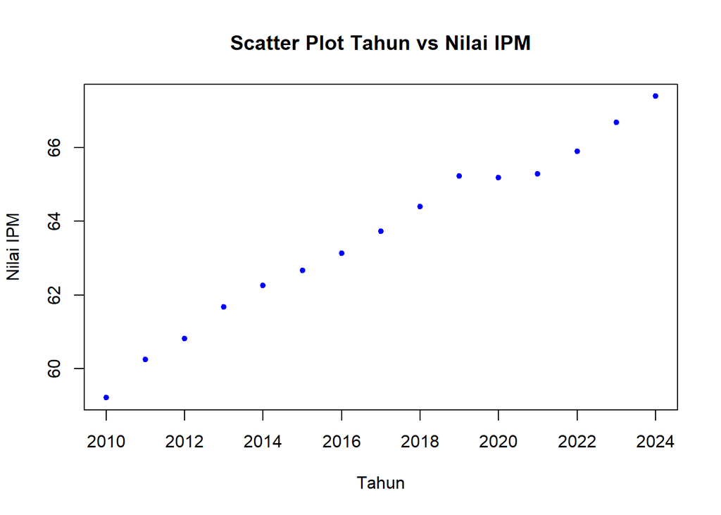

```r
plot(data1, pch = 20, col = "blue",
     main = "Scatter Plot Tahun vs Nilai IPM",
     xlab = "Tahun",
     ylab = "Nilai IPM")
```

# Regresi

```r
model <- lm(IPM ~ Tahun, data = data1)
summary(model)
```

```
##
## Call:
## lm(formula = IPM ~ Tahun, data = data1)
##
## Residuals:
##    Min     1Q Median     3Q    Max
## -0.603 -0.126  0.031  0.206  0.566
##
## Coefficients:
##               Estimate Std. Error t value Pr(>|t|)
## (Intercept) -1.024e+03  3.890e+01  -26.32 1.16e-12 ***
## Tahun        5.390e-01  1.928e-02   27.95 5.38e-13 ***
## ---
## Signif. codes:  0 '***' 0.001 '**' 0.01 '*' 0.05 '.' 0.1 ' ' 1
##
## Residual standard error: 0.3227 on 13 degrees of freedom
## Multiple R-squared:  0.9836, Adjusted R-squared:  0.9824
## F-statistic: 781.2 on 1 and 13 DF,  p-value: 5.38e-13
```

Model yang dihasilkan adalah

$$\text{IPM}_i = -1024 + 0.5390 \times
\text{Tahun}$$

Berdasarkan ringkasan model dapat diketahui bahwa hasil uji F memiliki p-value = 5.38e-13 < α (5%). Artinya, minimal terdapat satu variabel yang berpengaruh nyata terhadap model. Hasil uji-t parsial untuk kedua parameter regresi menunjukkan bahwa baik intersep (p-value = 1.16e-12) maupun koefisien regresi Tahun (p-value = 5.38e-13) signifikan pada taraf α = 5%.

Selanjutnya dapat dilihat nilai R-squared = 0.9836. Artinya, sebesar 98.36% keragaman nilai IPM dapat dijelaskan oleh variabel Tahun. Hasil ini menunjukkan model memiliki kecocokan yang sangat baik dengan data. Namun, kita perlu melakukan uji asumsi klasik terhadap residualnya.

# Uji Asumsi

## 1. Uji Normalitas Residual

```r
# Ambil residual numeric
residuals_numeric <- as.numeric(residuals(model))

# Shapiro-Wilk test
shapiro.test(residuals_numeric)
```

```
##
##  Shapiro-Wilk normality test
##
## data:  residuals_numeric
## W = 0.97088, p-value = 0.8709
```

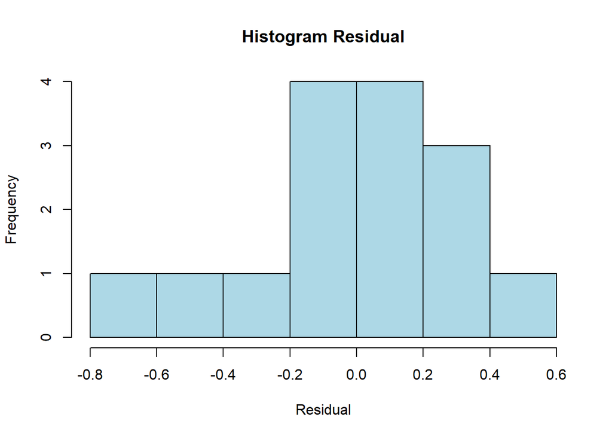

```r
# Visualisasi
hist(residuals_numeric, main="Histogram Residual", xlab="Residual", col="lightblue")
```

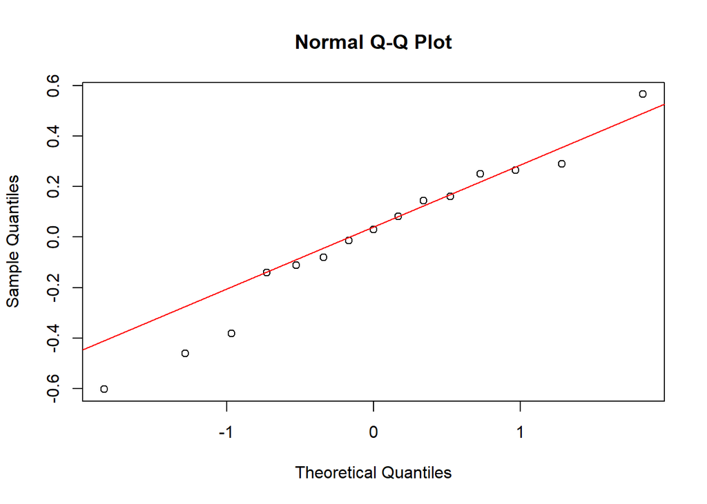

```r
qqnorm(residuals_numeric)
qqline(residuals_numeric, col="red")
```

p-value > 0,05 sehingga residual menyebar normal (asumsi terpenuhi).

## 2. Uji Heteroskedastisitas

```r
bptest(model)
```

```
##
##  studentized Breusch-Pagan test
##
## data:  model
## BP = 0.17459, df = 1, p-value = 0.6761
```

p-value > 0,05 sehingga asumsi homoskedastisitas terpenuhi.

## 3. Autokorelasi

*Durbin-Watson Test*

```r
dw_result <- dwtest(model)
dw_result
```

```
##
##  Durbin-Watson test
##
## data:  model
## DW = 0.82431, p-value = 0.001407
## alternative hypothesis: true autocorrelation is greater than 0
```

Nilai DW < 2 yang menunjukkan adanya autokorelasi positif.

*ACF (Autocorrelation Function)*

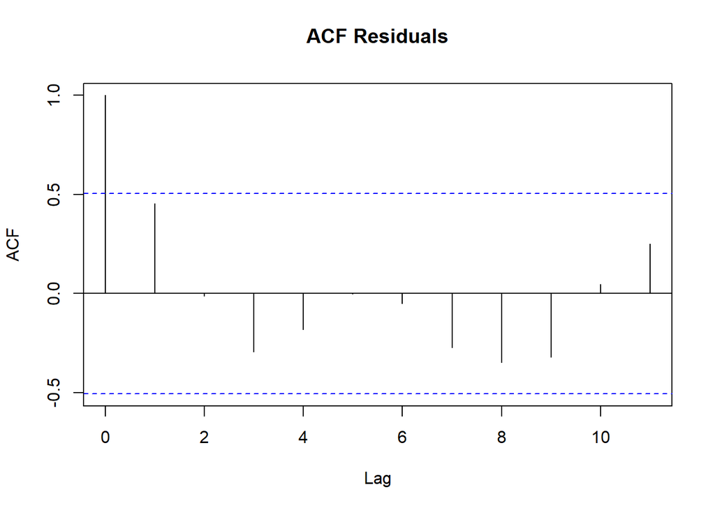

```r
acf(residuals_numeric, main="ACF Residuals")
```

*PACF (Partial Autocorrelation Function)*

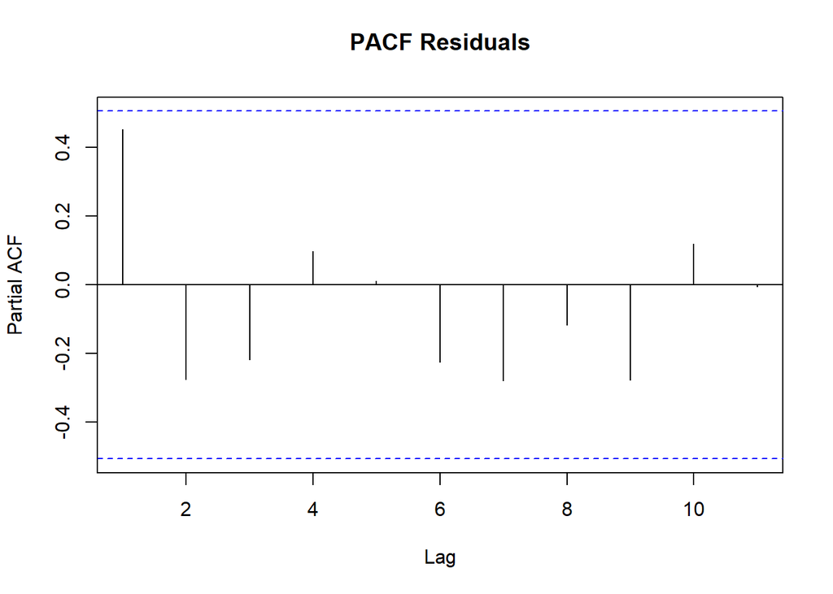

```r
pacf(residuals_numeric, main="PACF Residuals")
```

# Penanganan Autokorelasi

## Metode Cochrane-Orcutt

### Library

```r
install.packages("https://cran.r-project.org/src/contrib/Archive/orcutt/orcutt_2.0.tar.gz", repos = NULL, type = "source")
library(orcutt)
```

### Model

```r
modelCO <- cochrane.orcutt(model)
modelCO
```

```
## Cochrane-orcutt estimation for first order autocorrelation
##
## Call:
## lm(formula = IPM ~ Tahun, data = data1)
##
##  number of interaction: 25
##  rho 0.697992
##
## Durbin-Watson statistic
## (original):    0.82431 , p-value: 1.407e-03
## (transformed): 1.33424 , p-value: 4.672e-02
##
##  coefficients:
## (Intercept)       Tahun
## -1109.40784     0.58156
```

```r
#Rho optimum
rho<- modelCO$rho
rho
```

```
## [1] 0.6979917
```

Hasil yang dikeluarkan model setelah dilakukan penanganan adalah sebagai berikut.

$$\text{Y}_i = -1109.4078 + 0.58156
\times \text{Tahun}$$

Hasil juga menunjukkan bahwa nilai DW dan p-value meningkat menjadi 1.3342 dan 0.0467. Metode Cochrane-Orcutt berhasil mengurangi masalah autokorelasi. Meskipun DW transformed (1.33) masih belum ideal (idealnya mendekati 2), namun sudah jauh lebih baik dari kondisi awal (0.82).

Selanjutnya akan dilakukan transformasi secara manual dengan sintaks berikut ini.

```r
data1$IPM
```

```
##  [1] 67.39 66.68 65.90 65.28 65.19 65.23 64.39 63.73 63.13 62.67 62.26 61.68
## [13] 60.81 60.24 59.21
```

```r
data1$IPM[-1]
```

```
##  [1] 66.68 65.90 65.28 65.19 65.23 64.39 63.73 63.13 62.67 62.26 61.68 60.81
## [13] 60.24 59.21
```

```r
# Transformasi Manual
ipm.trans<- data1$IPM[-1]-data1$IPM[-15]*rho
tahun.trans<- data1$Tahun[-1]-data1$Tahun[-15]*rho
modelCOmanual<- lm(ipm.trans~tahun.trans)
summary(modelCOmanual)
```

```
##
## Call:
## lm(formula = ipm.trans ~ tahun.trans)
##
## Residuals:
##      Min       1Q   Median       3Q      Max
## -0.40900 -0.20103  0.00304  0.14776  0.57522
##
## Coefficients:
##              Estimate Std. Error t value Pr(>|t|)
## (Intercept) -335.0503    37.1061  -9.030 1.07e-06 ***
## tahun.trans    0.5816     0.0610   9.534 5.98e-07 ***
## ---
## Signif. codes:  0 '***' 0.001 '**' 0.01 '*' 0.05 '.' 0.1 ' ' 1
##
## Residual standard error: 0.2779 on 12 degrees of freedom
## Multiple R-squared:  0.8834, Adjusted R-squared:  0.8737
## F-statistic: 90.89 on 1 and 12 DF,  p-value: 5.983e-07
```

Hasil model transformasi bukan merupakan model sesungguhnya. Koefisien regresi masih perlu dicari kembali.

```r
#Mencari Penduga Koefisien Regresi setelah Transformasi ke Persamaan Awal
b0bintang <- modelCOmanual$coefficients[-2]
b0 <- b0bintang/(1-rho)
b1 <- modelCOmanual$coefficients[-1]
b0
```

```
## (Intercept)
##   -1109.408
```

```r
b1
```

```
## tahun.trans
##     0.58156
```

Hasil perhitungan koefisien regresi tersebut akan menghasilkan hasil yang sama dengan model yang dihasilkan menggunakan packages.

## Metode Hildreth-Lu

### Library

```r
library(HoRM)
```

### Model

```r
# Hildreth-Lu
hildreth.lu.func<- function(r, model){
  x <- model.matrix(model)[,-1]
  y <- model.response(model.frame(model))
  n <- length(y)
  t <- 2:n
  y <- y[t]-r*y[t-1]
  x <- x[t]-r*x[t-1]

  return(lm(y~x))
}
```

```r
#Pencariab rho yang meminimumkan SSE
r <- c(seq(0.1,0.9, by= 0.1))
tab <- data.frame("rho" = r, "SSE" = sapply(r, function(i){deviance(hildreth.lu.func(i, model))}))
round(tab, 4)
```

```
##   rho    SSE
## 1 0.1 1.2391
## 2 0.2 1.1433
## 3 0.3 1.0650
## 4 0.4 1.0041
## 5 0.5 0.9608
## 6 0.6 0.9349
## 7 0.7 0.9265
## 8 0.8 0.9356
## 9 0.9 0.9622
```

```r
#Rho optimal di sekitar 0.8
rOpt <- seq(0.6,0.8, by= 0.001)
tabOpt <- data.frame("rho" = rOpt, "SSE" = sapply(rOpt, function(i){deviance(hildreth.lu.func(i, model))}))
head(tabOpt[order(tabOpt$SSE),])
```

```
##       rho       SSE
## 99  0.698 0.9265112
## 98  0.697 0.9265121
## 100 0.699 0.9265121
## 97  0.696 0.9265147
## 101 0.700 0.9265147
## 96  0.695 0.9265190
```

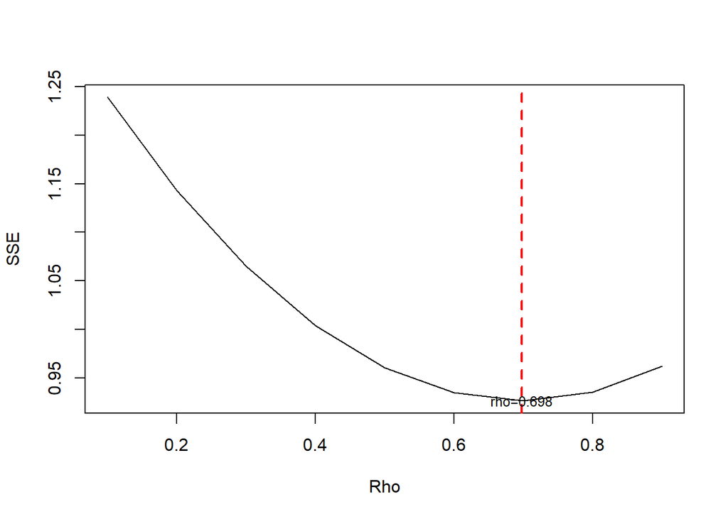

```r
#Grafik SSE optimum
par(mfrow = c(1,1))
plot(tab$SSE ~ tab$rho , type = "l", xlab = "Rho", ylab = "SSE")
abline(v = tabOpt[tabOpt$SSE==min(tabOpt$SSE),"rho"], lty = 2, col="red",lwd=2)
text(x=0.698, y=0.9265112, labels = "rho=0.698", cex = 0.8)
```

Perhitungan yang dilakukan aplikasi R menunjukkan bahwa nilai ρ optimum, yaitu saat SSE terkecil terdapat pada nilai ρ=0.698. Hal tersebut juga ditunjukkan pada plot. Selanjutnya, model dapat didapatkan dengan mengevaluasi nilai ρ ke dalam fungsi hildreth.lu.func, serta dilanjutkan dengan pengujian autokorelasi dengan uji Durbin-Watson. Namun, setelah pengecekan tersebut tidak lupa koefisien regresi tersebut digunakan untuk transformasi balik. Persamaan hasil transformasi itulah yang menjadi persamaan sesungguhnya.

```r
#Model terbaik
modelHL <- hildreth.lu.func(0.698, model)
summary(modelHL)
```

```
##
## Call:
## lm(formula = y ~ x)
##
## Residuals:
##      Min       1Q   Median       3Q      Max
## -0.40900 -0.20103  0.00304  0.14776  0.57522
##
## Coefficients:
##              Estimate Std. Error t value Pr(>|t|)
## (Intercept) -335.0422    37.1061  -9.029 1.07e-06 ***
## x              0.5816     0.0610   9.534 5.99e-07 ***
## ---
## Signif. codes:  0 '***' 0.001 '**' 0.01 '*' 0.05 '.' 0.1 ' ' 1
##
## Residual standard error: 0.2779 on 12 degrees of freedom
## Multiple R-squared:  0.8834, Adjusted R-squared:  0.8737
## F-statistic: 90.89 on 1 and 12 DF,  p-value: 5.985e-07
```

```r
#Transformasi Balik
cat("y = ", coef(modelHL)[1]/(1-0.698), "+", coef(modelHL)[2],"x", sep = "")
```

```
## y = -1109.411+0.5815617x
```

```r
#Deteksi autokorelasi
dwtest(modelHL)
```

```
##
##  Durbin-Watson test
##
## data:  modelHL
## DW = 1.3343, p-value = 0.04673
## alternative hypothesis: true autocorrelation is greater than 0
```

Hal tersebut menujukkan p-value sebesar 0.0467,di mana p-value < α =5%. Artinya tolak H0 atau cukup bukti untuk menyatakan bahwa ada autokorelasi dalam data nilai IPM dengan metode Hildreth-Lu pada taraf nyata 5%.

Terakhir, akan dibandingkan nilai SSE dari ketiga metode (metode awal, metode Cochrane-Orcutt, dan Hildreth-Lu).

```r
#Perbandingan
sseModelawal <- anova(model)$`Sum Sq`[-1]
sseModelCO <- anova(modelCOmanual)$`Sum Sq`[-1]
sseModelHL <- anova(modelHL)$`Sum Sq`[-1]
mseModelawal <- sseModelawal/length(data1$IPM)
mseModelCO <- sseModelCO/length(data1$IPM)
mseModelHL <- sseModelHL/length(data1$IPM)
akurasi <- matrix(c(sseModelawal,sseModelCO,sseModelHL,
                    mseModelawal,mseModelCO,mseModelHL),nrow=2,ncol=3,byrow = T)
colnames(akurasi) <- c("Model Awal", "Model Cochrane-Orcutt", "Model Hildreth-Lu")
row.names(akurasi) <- c("SSE","MSE")
akurasi
```

```
##     Model Awal Model Cochrane-Orcutt Model Hildreth-Lu
## SSE 1.35368000            0.92651122        0.92651122
## MSE 0.09024533            0.06176741        0.06176741
```

Berdasarkan hasil tersebut dapat diketahui bahwa hasil penanganan autokorelasi dengan metode Cochrane-Orcutt dan Hildreth-Lu memiliki SSE yang sama.

Autokorelasi yang terdapat pada data IPM terjadi akibat adanya korelasi di antara unsur penyusunnya. Indikator IPM yang erat hubungannya dengan perekonomian sangat rawan menjadi penyebab adanya autokorelasi. Autokorelasi dapat dideteksi secara eksploratif melalui plot sisaan, ACF, dan PACF, serta dengan uji formal Durbin-Watson. Namun, autokorelasi pada data IPM NTT belum dapat ditangani dengan metode Cochrane-Orcutt dan Hildreth-Lu sehingga memerlukan penanganan lain.